# Individual assignment SBD

Hagen Aad Fock

ADS, 2021-2022

# 0. Prepare

$\blacktriangleright$ Load the R-packages you will use.

```r
library(fpp3)
library(tseries)
library(tidyverse)    # alternatively, this also loads %>%
library(knitr)
library(mice) # for missing data imputation
library(VIM)
library(expsmooth)
```

$\blacktriangleright$ Include R-code you used to load (and prepare) the data.

## 0.1 Checking for missing data

```r
set.seed(666)

esmdata <- read.csv("../ESMdata/ESMdata.csv")

missing_values <- esmdata %>%
  summarize_all(funs(sum(is.na(.))/n())) %>%
  gather(key="feature", value="missing_pct")
```

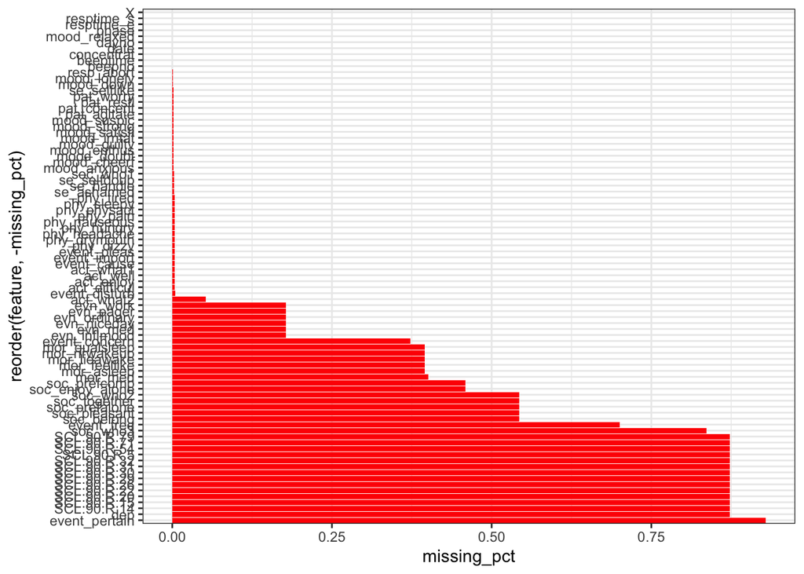

```r
missing_values %>%
  ggplot(aes(x=reorder(feature,-missing_pct),y=missing_pct)) +
  geom_bar(stat="identity",fill="red")+
  coord_flip()+theme_bw()
```

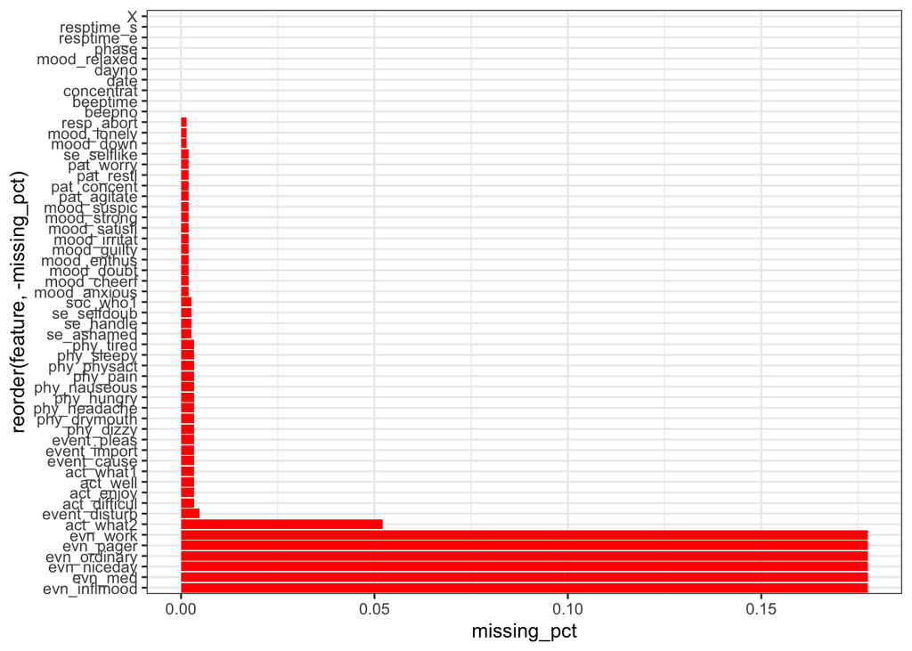

```r
missing_values[missing_values$missing_pct < 0.25,] %>%
  ggplot(aes(x=reorder(feature,-missing_pct),y=missing_pct)) +
  geom_bar(stat="identity",fill="red")+
  coord_flip()+theme_bw()
```

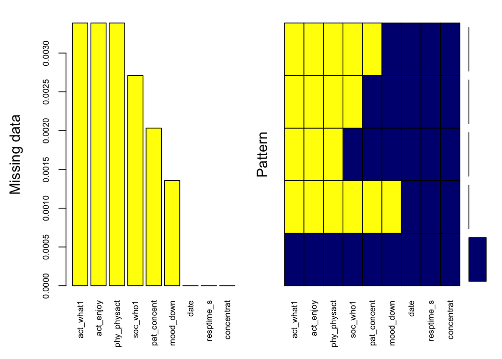

```
##
##  Variables sorted by number of missings:
##     Variable       Count
##    act_what1 0.003387534
##    act_enjoy 0.003387534
##  phy_physact 0.003387534
##     soc_who1 0.002710027
##  pat_concent 0.002032520
##    mood_down 0.001355014
##         date 0.000000000
##   resptime_s 0.000000000
##   concentrat 0.000000000
```

```r
relevant_variables <- c('date', 'resptime_s',  'concentrat',
                        'mood_down',
                        'pat_concent',
                        'act_what1','act_enjoy',
                        'phy_physact',
                        'soc_who1')
mice_plot <- aggr(esmdata[,relevant_variables], col=c('navyblue','yellow'),
                    numbers=TRUE, sortVars=TRUE,
                    labels=names(relevant_variables), cex.axis=.7,
                    gap=3, ylab=c("Missing data","Pattern"))
```

```r
imputed_esmdata <- esmdata[,relevant_variables] %>%
  mice(m=5, maxit = 50, method = 'pmm', seed = 666) %>%
  complete()
```

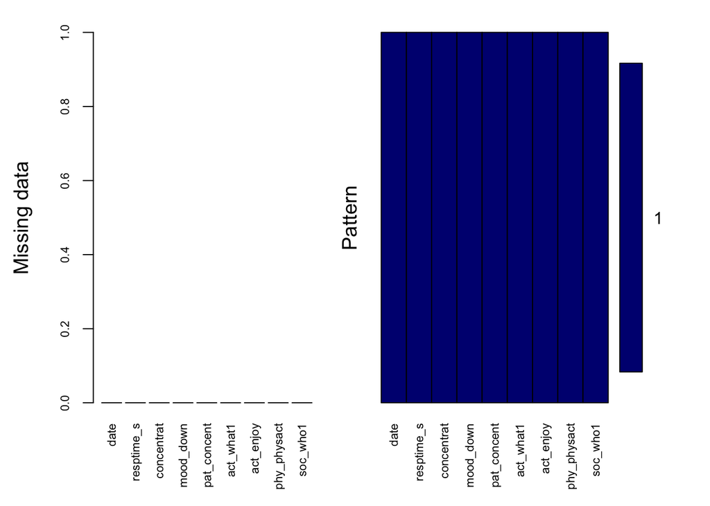

```
##
##  Variables sorted by number of missings:
##     Variable Count
##         date     0
##   resptime_s     0
##   concentrat     0
##    mood_down     0
##  pat_concent     0
##    act_what1     0
##    act_enjoy     0
##  phy_physact     0
##     soc_who1     0
```

```r
mice_plot <- aggr(imputed_esmdata, col=c('navyblue','yellow'),
                    numbers=TRUE, sortVars=TRUE,
                    labels=names(imputed_esmdata), cex.axis=.7,
                    gap=3, ylab=c("Missing data","Pattern"))
```

Now that every missing data was imputed we can make the tsibble.

```r
create_date_time <- function(date, time) {
  return(dmy_hms(paste(date, time, sep=" ")))
}

esmdata <- esmdata %>%
  mutate(date_time = create_date_time(date, resptime_s))

esmdata$date <- dmy(esmdata$date)

all_data <- esmdata %>%
  as_tsibble(index = date_time)

daily_record <- esmdata %>%
  filter(!duplicated(esmdata$date)) %>%
  as_tsibble(index = date_time)

narrowed <- imputed_esmdata  %>%
  mutate(date_time = create_date_time(date, resptime_s)) %>%
  as_tsibble(index = date_time)
```

# 1. General

$\blacktriangleright$ To be able to use fpp3, the data have to be a tsibble object. If they aren’t already, transform them. Describe the structure of this object.

## 1.1. Describe your data

The data is about a man that was reducing his anti depression medication. Every variable that will be stated within this section was measured using a semi-random experience-sampling protocol. “The participant collected reports of momentary states up to 10 times a day over a period of 239 days.” https://doi.org/10.1159/000441458

“Depression is a mood disorder that causes a persistent feeling of sadness and loss of interest. Also called major depressive disorder or clinical depression, it affects how you feel, think and behave and can lead to a variety of emotional and physical problems. You may have trouble doing normal day-to-day activities, and sometimes you may feel as if life isn’t worth living.” https://www.mayoclinic.org/diseases-conditions/depression/symptoms-causes/syc-20356007

$\blacktriangleright$ What is your outcome variable; how was it measured (how many times, how frequently, etc.)?

Regarding the information from the article about depression I derived following variables as potential outcome variables:

I don’t have many experience regarding depression but I assume that depression is simplified a bad mood over a longer period. Therefore, I derived all mood variables and came up with a mixed mood variable. I call it the depression factor.

Because the scales are not always displayed by the same scale I had to normalize them. I transformed all scales to the scheme (-100, 100) so minus values indicate a bad influence for the mood and positive values indicate good moods. Also I wanted to make the range bigger so the changes are more visible.

| name | description | scale | ~ missing % |
| --- | --- | --- | --- |
| `mood_relaxed` | I feel relaxed | positive ( 1, 7) | 0% |
| `mood_satisfi` | I feel satisfied | positive ( 1, 7) | 0.2% |
| `mood_enthus` | I feel enthusiastic | positive ( 1, 7) | 0.2% |
| `mood_cheerf` | I feel cheerful | positive ( 1, 7) | 0.2% |
| `mood_strong` | I feel strong | positive ( 1, 7) | 0.2% |
| `se_selflike` | I like myself | positive ( 1, 7) | 0.2% |
| `se_handle` | I can handle anything | positive ( 1, 7) | 0.3% |
| `mood_irritat` | I feel irritated | negative ( 1, 7) | 0.2% |
| `mood_suspic` | I feel suspicious | negative ( 1, 7) | 0.2% |
| `mood_doubt` | I feel indecisive | negative ( 1, 7) | 0.2% |
| `se_ashamed` | I am ashamed of myself | negative ( 1, 7) | 0.3% |
| `se_selfdoub` | I doubt myself | negative ( 1, 7) | 0.3% |
| `mood_down` | I feel down | negative (-3, 3) | 0.1% |
| `mood_lonely` | I feel lonely | negative (-3, 3) | 0.1% |
| `mood_anxious` | I feel anxious | negative (-3, 3) | 0.2% |
| `mood_guilty` | I feel guilty | negative (-3, 3) | 0.2% |

$\blacktriangleright$ What are the predictor variable(s) you will consider? Why would this make sense as a predictor?

I assume that physical condition, and the previous day might be predictor. For example when the patient is in pain he might feel more depressed and or the previous day was an nice day he is more motivated about the upcoming day.

| name | description | scale | ~ missing % |
| --- | --- | --- | --- |
| `phy_hungry` | I am hungry | negative ( 1, 7) | 0.3% |
| `phy_tired` | I am tired | negative ( 1, 7) | 0.3% |
| `phy_pain` | I am in pain | negative ( 1, 7) | 0.3% |
| `phy_dizzy` | I feel dizzy | negative ( 1, 7) | 0.3% |
| `phy_headache` | I have a headache | negative ( 1, 7) | 0.3% |

$\blacktriangleright$ What are the cause(s) you will consider? Why would this make sense as a cause?

I assume that a human being is complex but an encapsulated system on its own. But the surrounding factors influence whatever happens within a person. So I assume all activities with the environment like meeting people or doing something actively must be the cause of how the human being feels and also everything a person takes to him influences the internal behavior.

[output not shown]

```r
missing_values[missing_values$missing_pct > 0.20,]$feature
```

```
##  [1] "soc_enjoy_alone" "soc_prefcomp"    "soc_who2"        "soc_who3"
##  [5] "soc_belong"      "soc_pleasant"    "soc_prefalone"   "soc_together"
##  [9] "event_concern"   "event_freq"      "event_pertain"   "mor_asleep"
## [13] "mor_nrwakeup"    "mor_lieawake"    "mor_qualsleep"   "mor_feellike"
## [17] "mor_med"         "SCL.90.R.14"     "SCL.90.R.20"     "SCL.90.R.22"
## [21] "SCL.90.R.5"      "SCL.90.R.29"     "SCL.90.R.26"     "SCL.90.R.15"
## [25] "SCL.90.R.30"     "SCL.90.R.31"     "SCL.90.R.32"     "SCL.90.R.54"
## [29] "SCL.90.R.71"     "SCL.90.R.79"     "dep"
```

```r
missing_values[missing_values$feature == 'act_enjoy',]$missing_pct
```

```
## [1] 0.003387534
```

```r
# the variable declaration is following
# _positive indicating if the highest value is a good mood
# _negative indicating if the highest value is a depressive mood
# _17       indicating if the scale is ( 1, 7)
# _33       indicating if the scale is (-3, 3)

# Data Normalization – Min-Max Normalization
# from (-3, 3) to (-100, 100)
normalize <- function(atr)(
  return((atr - (-3)) / (3 - (-3)) * (100 - (-100)) + (-100))
)

# For attributes on a scale (1, 7) where 1 indicates a depressive value.
normalize_positive_17 <-  function(atr) (
  return(normalize(atr - 4))
)

normalize_negative_17 <- function(atr) (
  return(normalize((atr - 4) * -1))
)

# For attributes on a scale(-3, 3) where 3 is a depressive value.
normalize_negative_33 <- function(atr) (
  return(normalize(atr * -1))
)
```

## 1.2. Visualize your data

$\blacktriangleright$ Create a sequence plot of the data with the function autoplot(). Interpret the results.

```r
'autoplot(daily_record_agr, mood_down) +
  labs(title = "Depression records (all samples)",
       subtitle = "Mood of patiant",
       y = "Feeling down [-3(not), 3(very)]")

autoplot(daily_record, mood_down) +
  labs(title = "Depression records (all samples)",
       subtitle = "Mood of patiant",
       y = "Feeling down [-3(not), 3(very)]")'
```

[output not shown]

$\blacktriangleright$ Plot the autocorrelation function with the function acf(). Interpret the results.

```r
'daily_record_agr'
```

```
## [1] "daily_record_agr"
```

```r
'par(mfrow=c(2,2))
acf(daily_record_agr[3])
acf(daily_record_agr[4])
acf(daily_record_agr[5])
acf(daily_record_agr[6])'
```

```
## [1] "par(mfrow=c(2,2))\nacf(daily_record_agr[3])\nacf(daily_record_agr[4])\nacf(daily_record_agr[5])\nacf(daily_record_agr[6])"
```

$\blacktriangleright$ Based on (basic) content knowledge about the variable, and these visualizations, is there reason to assume the data are non-stationary and/or that there is a seasonal component?

# 2. Forecasting

## 2.1. SARIMA modeling

$\blacktriangleright$ Perform the Dickey-Fuller test. What is your conclusion?

```r
'z <- c(daily_record_agr$mood_down)
z2 <- tibble(mood_down = daily_record$mood_down, date_time = daily_record$date_time)
z2 <- fill_gaps(z2)'
```

```
## [1] "z <- c(daily_record_agr$mood_down)\nz2 <- tibble(mood_down = daily_record$mood_down, date_time = daily_record$date_time)\nz2 <- fill_gaps(z2)"
```

```r
'adf.test(z)'
```

```
## [1] "adf.test(z)"
```

$\blacktriangleright$ Fit an (S)ARIMA model to the data; what is the order of the model that was selected?

```r
'dat <- tibble(date=daily_record_agr$Group.1, z=daily_record_agr$mood_down)
dat <- as_tsibble(dat, index=date)

dat2 <- as_tsibble(z2, index = date_time)'
```

```
## [1] "dat <- tibble(date=daily_record_agr$Group.1, z=daily_record_agr$mood_down)\ndat <- as_tsibble(dat, index=date)\n\ndat2 <- as_tsibble(z2, index = date_time)"
```

```r
'dat %>% model(ARIMA(z)) -> fit_z
report(fit_z)

dat2 <- dat2 %>% fill_gaps()
dat2 %>% model(ARIMA(z2)) -> fit_z2
report(fit_z2)'
```

```
## [1] "dat %>% model(ARIMA(z)) -> fit_z\nreport(fit_z)\n\ndat2 <- dat2 %>% fill_gaps()\ndat2 %>% model(ARIMA(z2)) -> fit_z2\nreport(fit_z2)"
```

$\blacktriangleright$ Check the residuals of the model using the function gg_tsresiduals(). What is your conclusion?

```r
'gg_tsresiduals(fit_z)'
```

```
## [1] "gg_tsresiduals(fit_z)"
```

```r
'dat %>% model(ARIMA(z ~ pdq(p=1, d=0, q=1))) -> fit2_z
report(fit2_z)'
```

```
## [1] "dat %>% model(ARIMA(z ~ pdq(p=1, d=0, q=1))) -> fit2_z\nreport(fit2_z)"
```

```r
'gg_tsresiduals(fit2_z)'
```

```
## [1] "gg_tsresiduals(fit2_z)"
```

## 2.2. Dynamic regression

$\blacktriangleright$ Include the predictor in an dynamic regression model (i.e., allow for (S)ARIMA residuals); what is the effect of the predictor?

$\blacktriangleright$ What order is the (S)ARIMA model for the residuals?

$\blacktriangleright$ Check the residuals of the model using the function gg_tsresiduals(). What is your conclusion?

## 2.3. Forecasts

$\blacktriangleright$ Choose a forecasting horizon, and indicate why this is a reasonable and interesting horizon to consider.

$\blacktriangleright$ Create forecasts based on the model without the predictor and plot these.

$\blacktriangleright$ Create forecasts based on the model with the predictor and plot these.

$\blacktriangleright$ Compare the plots of both forecasts (visually), and discuss how they are similar and/or different.

# 3. Causal Modeling

*TBA*